# Simulation Report

2021-10-28

## Poulation value

| omega | tau0 | tau1 | difficulty |
| --- | --- | --- | --- |
| 0.2 | 0.13 | -0.06 | N(0, 1) |

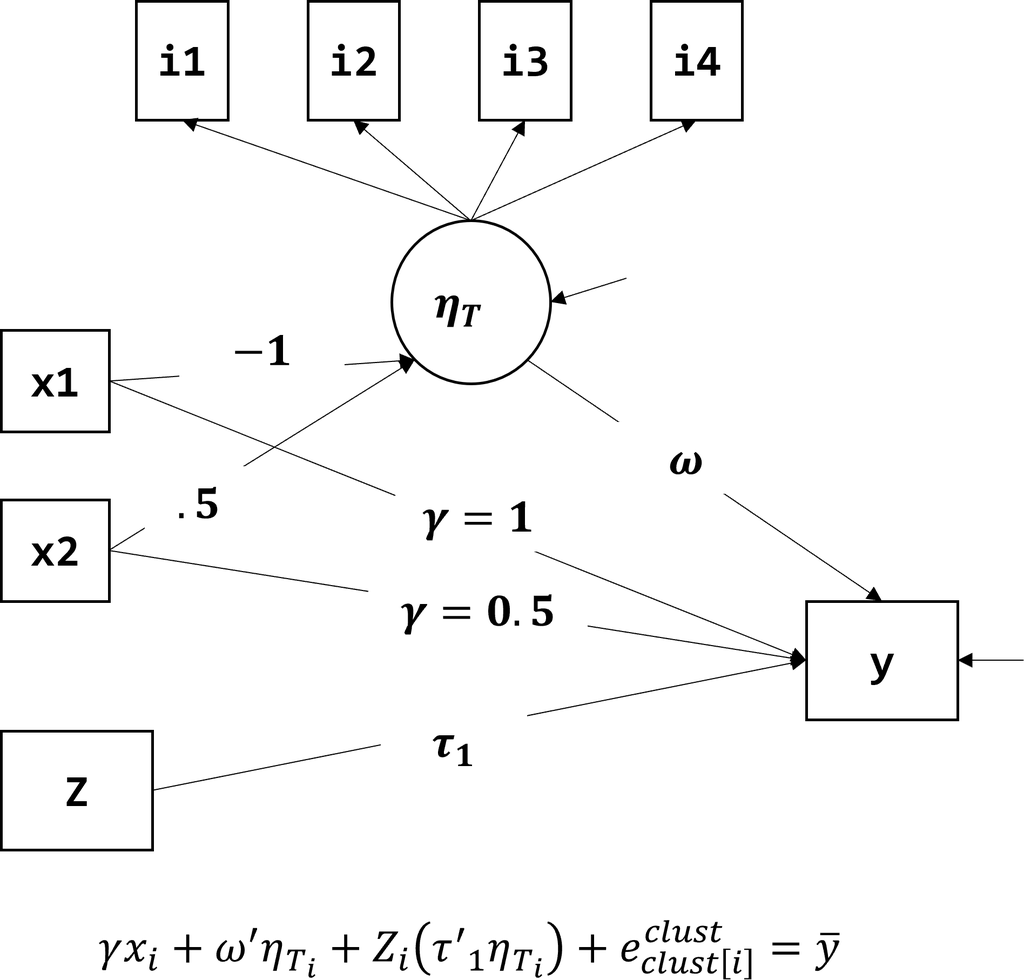

## Condition

[output not shown]

## Results

### Model fit

- R-hat
  - Compromise between the within and between variance
  - Reduces to 1 as N -> infinity
  - Acceptable convergence (chains are stationary and mix well) when R-hat < 1.1. Greater values are usually indictive of problems in the model.
- Geweke Diagnostic
  - Compare first part of chain with last part (after warmup period). The default is first 10% with last 50%.
  - If the samples are drawn from the same posterior distribution, the two means are equal
  - The test statistic is a standard unpaired Z-test: the difference between the two sample means divided by its estimated standard error, so it should be between -2 and 2 if the chain has converged to its stationary distribution.
  - If significant, then warmup period is too small or need a longer sequence of parameter values for convergence.
- Heidelberg-Welch Diagnostic
  - Tells whether we have converged and if we have run our MCMC long enough
  - Null hypothesis that the sample values come from a stationary distribution
  - First the whole chain is assessed. Then 10% of the first part of the chain is discarded, and then assessed again. Then 20% of the first part of the chain is discarded, then assessed again. Continues until null is ‘accepted’ or 50% of the chain has been discarded.
  - The latter outcome constitutes “failure” of the stationary test and indicates that a longer MCMC run is needed.
  - If the stationary test is passed, the number of iterations to keep and the number to discard (warm-up) are reported.
    - If passed, then the half-width test is performed.
    - The ratio of the margin of error (the half-width) for a confidence interval is compared to the estimated mean.
    - If this ratio is less than $\epsilon$, some desired level of precision, then the chain is long enough. The Monte Carlo error of the MCMC sequence is low.
    - If this ratio is more than $\epsilon$, the chain should be extended.
- Not included: effective sample size, Raftery, Gelman, Monte Carlo SE.

#### Model fit summary

| sample_size | lambda | nsec | Rhat | geweke | heidel |
| --- | --- | --- | --- | --- | --- |
| 1000 | 10 | 20 | 1.00100 | 0.65 | 0.3 |
| 1000 | 40 | 100 | 1.00130 | 0.60 | 0.1 |
| 4000 | 10 | 20 | 1.00105 | 0.55 | 0.5 |
| 4000 | 40 | 100 | 1.00090 | 0.80 | 0.8 |

#### Convergence summary

Geweke = 1 and Heidel = 1

| sample_size | lambda | nsec | n |
| --- | --- | --- | --- |
| 1000 | 10 | 20 | 4 |
| 4000 | 10 | 20 | 6 |
| 4000 | 40 | 100 | 13 |

Geweke = 0 and Heidel = 0

| sample_size | lambda | nsec | n |
| --- | --- | --- | --- |
| 1000 | 10 | 20 | 5 |
| 1000 | 40 | 100 | 6 |
| 4000 | 10 | 20 | 5 |
| 4000 | 40 | 100 | 1 |

#### Partial convergence summary

Geweke = 0 and Heidel = 1

| sample_size | lambda | nsec | n |
| --- | --- | --- | --- |
| 1000 | 10 | 20 | 2 |
| 1000 | 40 | 100 | 2 |
| 4000 | 10 | 20 | 4 |
| 4000 | 40 | 100 | 3 |

Geweke = 1 and Heidel = 0

| sample_size | lambda | nsec | n |
| --- | --- | --- | --- |
| 1000 | 10 | 20 | 9 |
| 1000 | 40 | 100 | 12 |
| 4000 | 10 | 20 | 5 |
| 4000 | 40 | 100 | 3 |

### main treatment effect

#### Combined

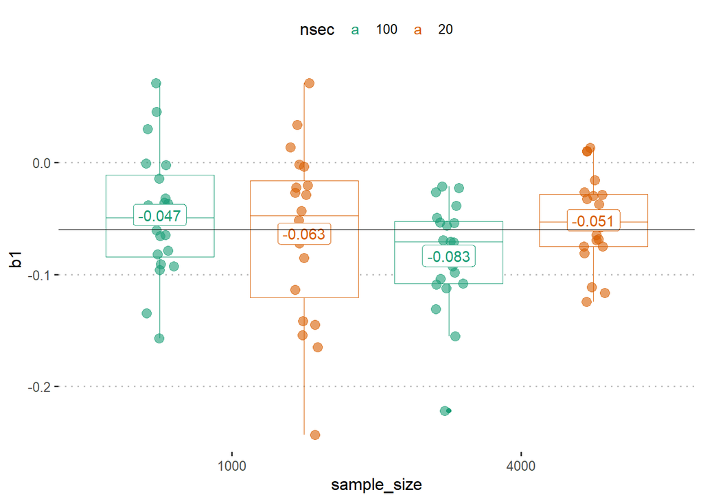

#### By Geweke

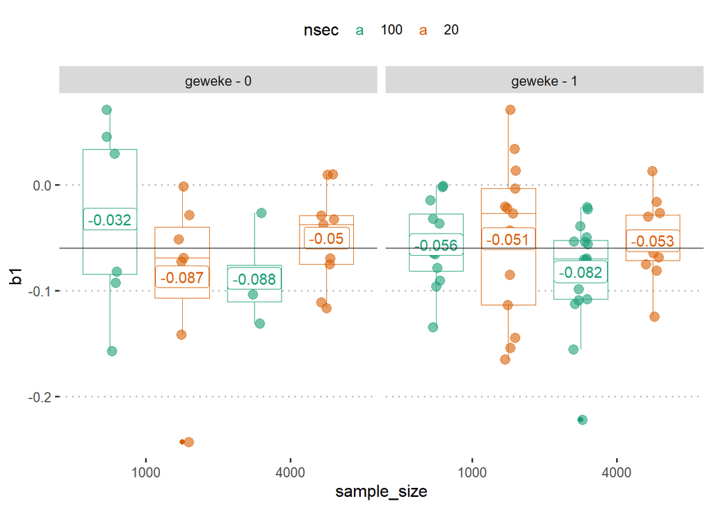

#### By Heidel

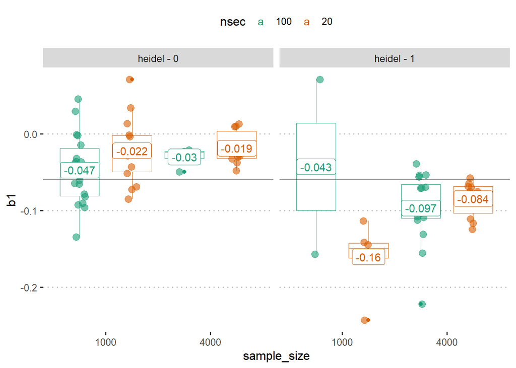

#### By Geweke and Heidel

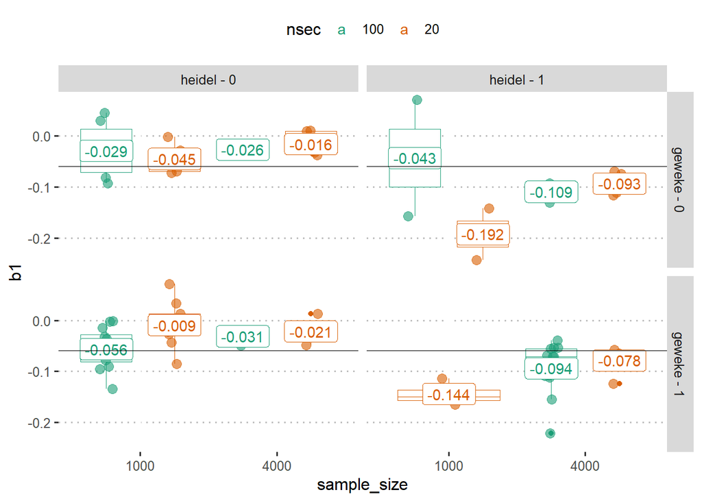

### main effect

#### Combined

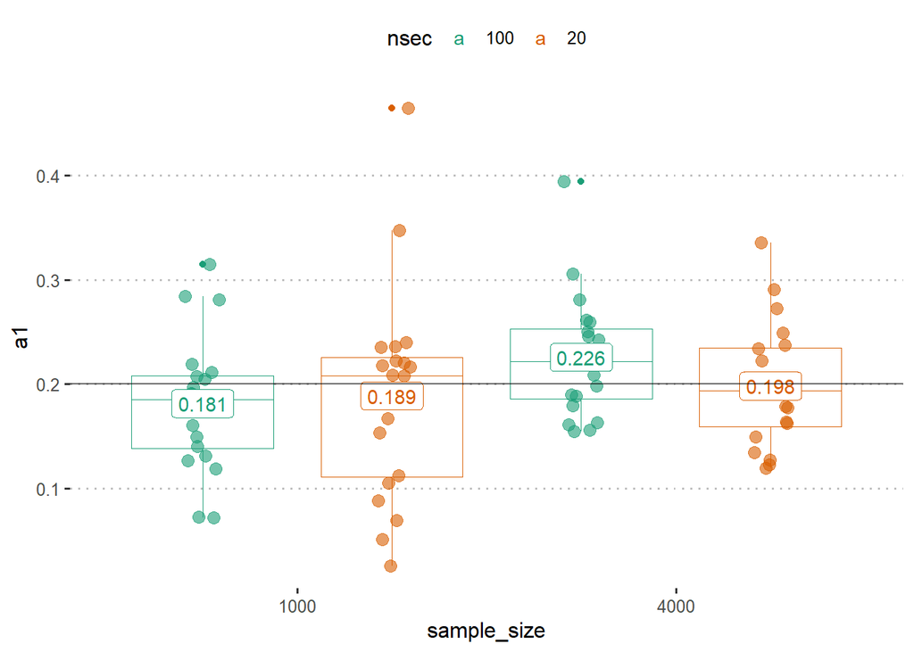

#### By Geweke

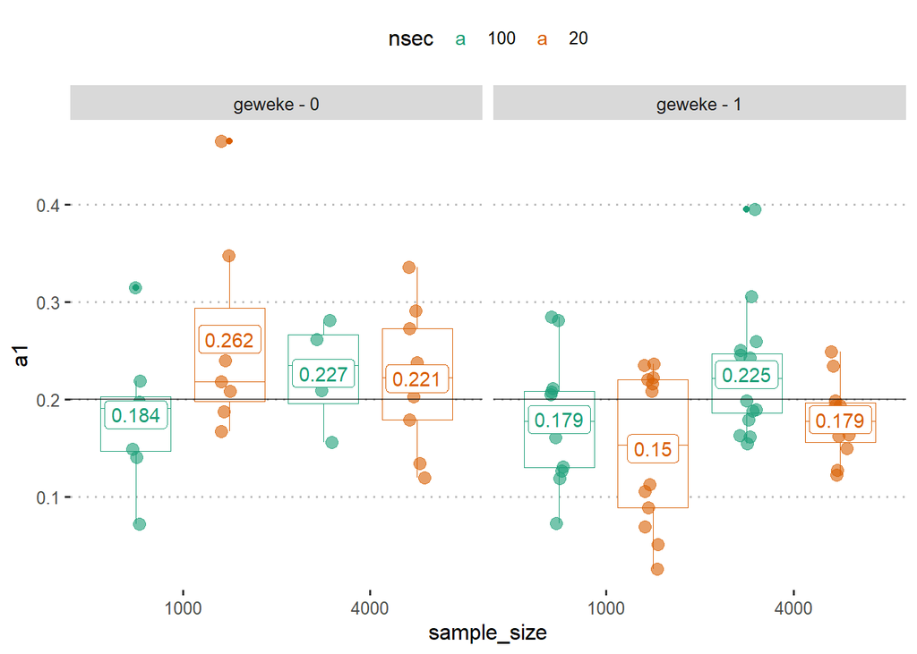

#### By Heidel

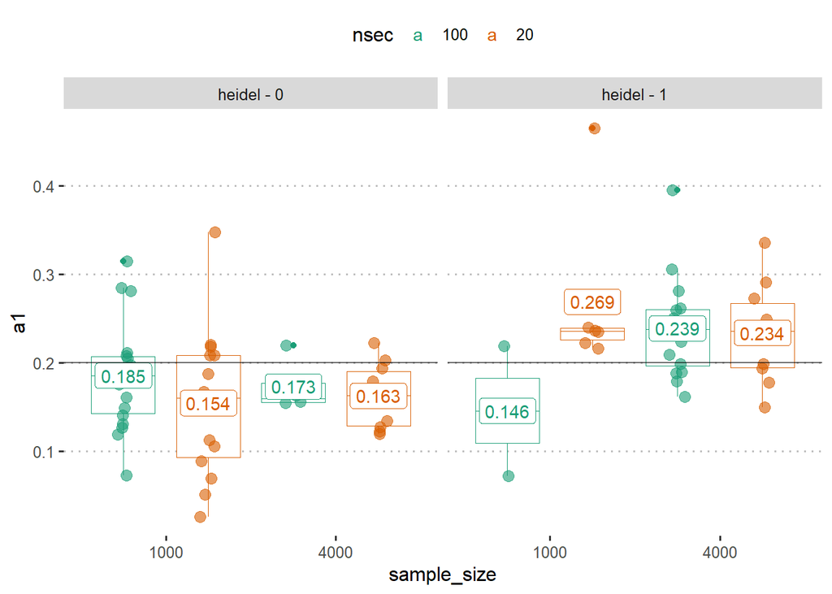

#### By Geweke and Heidel

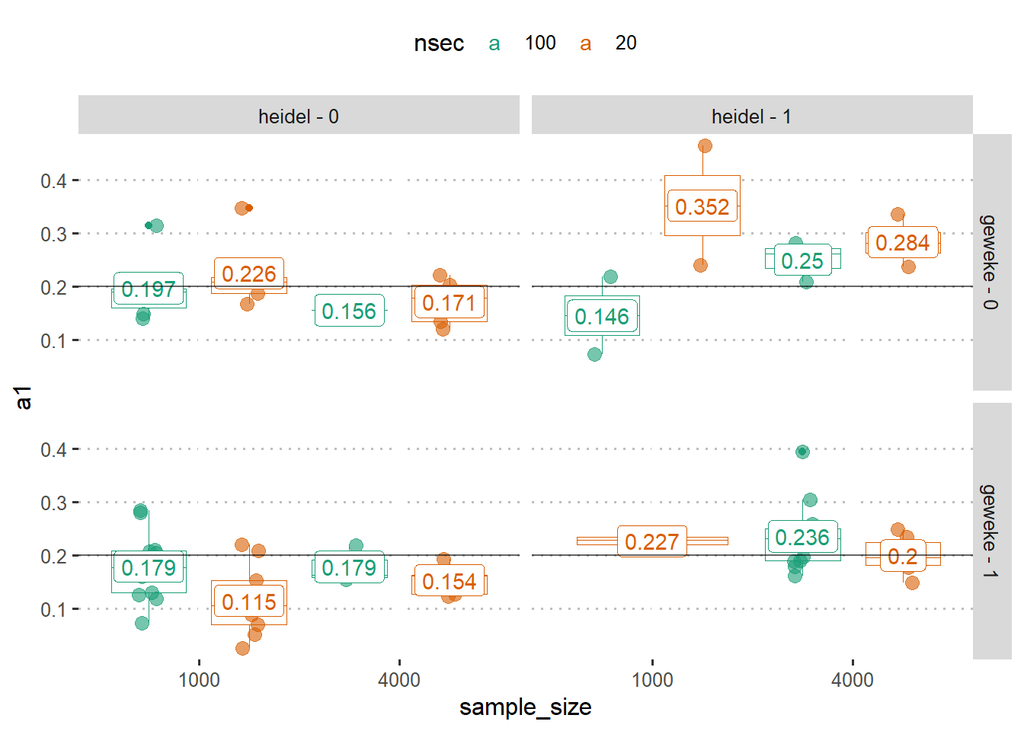

## Rasch model

| sample_size | lambda | nsec | geweke | heidel | Rhat | b_bias |
| --- | --- | --- | --- | --- | --- | --- |
| 1000 | 10 | 20 | geweke - 0 | heidel - 0 | 1.000600 | 0.003 |
| 1000 | 10 | 20 | geweke - 0 | heidel - 1 | 1.002500 | -0.020 |
| 1000 | 10 | 20 | geweke - 1 | heidel - 0 | 1.001000 | 0.026 |
| 1000 | 10 | 20 | geweke - 1 | heidel - 1 | 1.000750 | 0.011 |
| 1000 | 40 | 100 | geweke - 0 | heidel - 0 | 1.001000 | 0.004 |
| 1000 | 40 | 100 | geweke - 0 | heidel - 1 | 1.001000 | -0.062 |
| 1000 | 40 | 100 | geweke - 1 | heidel - 0 | 1.001500 | 0.010 |
| 4000 | 10 | 20 | geweke - 0 | heidel - 0 | 1.001200 | 0.016 |
| 4000 | 10 | 20 | geweke - 0 | heidel - 1 | 1.001000 | -0.008 |
| 4000 | 10 | 20 | geweke - 1 | heidel - 0 | 1.001000 | -0.008 |
| 4000 | 10 | 20 | geweke - 1 | heidel - 1 | 1.001000 | -0.002 |
| 4000 | 40 | 100 | geweke - 0 | heidel - 0 | 1.000000 | 0.036 |
| 4000 | 40 | 100 | geweke - 0 | heidel - 1 | 1.002000 | 0.002 |
| 4000 | 40 | 100 | geweke - 1 | heidel - 0 | 1.000000 | -0.001 |
| 4000 | 40 | 100 | geweke - 1 | heidel - 1 | 1.000923 | 0.005 |